# Part I - (PISA Data Exploration)

# Observation 12

- There is a high correlation between science and math (r=0.9) and science and reading (r=0.88), and math and reading (r=0.86).

# Question 13

- Is there any correlation bwtween the family structure, if the student is from an OECD country or not in regards to the scores?

I used 3 variables(Family structure, OECD and thier various score points), to see if there is a significant impact on thier performance by any of variables.

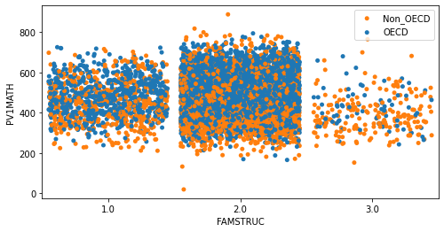

```python
# create a sample
student_0 = student_new[student_new['FAMSTRUC'].notnull()]
student_1 = student_0.sample(10000)
#Plot using the sample of 10k student.
#Plot the maths variable.
plt.figure(figsize = [8, 4])
sb.stripplot(x='FAMSTRUC', y='PV1MATH', hue='OECD', data=student_1, jitter=0.45)
plt.legend(title=None, loc='upper right', labels=['Non_OECD', 'OECD'])
```

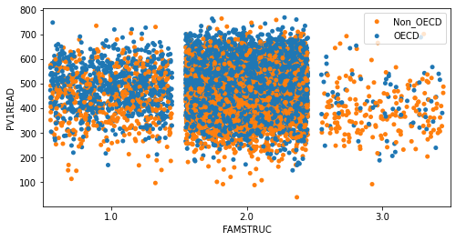

```python
plt.figure(figsize = [8, 4])
sb.stripplot(x='FAMSTRUC', y='PV1READ', hue='OECD', data=student_1, jitter=0.45)
plt.legend(title=None, loc='upper right', labels=['Non_OECD', 'OECD'])
```

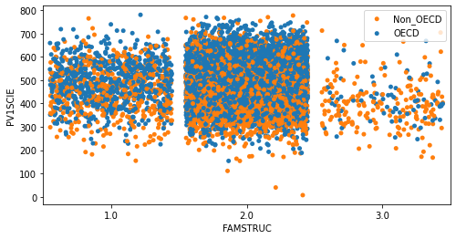

```python
plt.figure(figsize = [8, 4])
sb.stripplot(x='FAMSTRUC', y='PV1SCIE', hue='OECD', data=student_1, jitter=0.45)
plt.legend(title=None, loc='upper right', labels=['Non_OECD', 'OECD'])
```

# Observation 13

- From the above charts, we will notice that when it comes to the family size in relation to their scores,lots of the students come from a 2 family structure. Then the 1 family structure is next and the least amount of student come from 3 family structure. When we used the OECD status, both OECD and Non-OECD countries , have less students from a 3 family structure. and favor a 2 family structure and their perfomance is not really significant.

# Conclusion

--- Univaraite exploration

- We see that all score variables follow a normal mean distribution,with scores ranging from 200 - 800 points and from all 3 scores we can see that majority of the students have the mean score of 500 points.
- From the above plot, we see that alot of the students come from a 2 family structure, over 350.000+
- Student from OECD countries are higher than Non_OECD
- The difference between the female and male students is really not too significant but there are more female students.

--- Bivaraite exploration

--- Multivariate exploration

- From the multivaraiate, we will notice that when it comes to the family size in relation to their scores,lots of the students come from a 2 family structure. Then the 1 family structure is next and the least amount of student come from 3 family structure. When we used the OECD status, both OECD and Non-OECD countires , have less students from a 3 family structure. and favor a 2 family structure and their perfomance is not really significant.

In conclusion, this analysis confirms that there are a number of different variables, that has potential effects on the preparation of students for their future life.